# model_fit

load libraries and clean data

```r
library(readr)
library(tidyverse)
library(boot)
library(glmnet)
library(caret)
library(pROC)
library(MASS)
```

```r
library(ggplot2)

set.seed(445)

bank_full <- read_delim("data/bank-full_1.csv",
    delim = ";", escape_double = FALSE, trim_ws = TRUE)
bank_full$y <- factor(bank_full$y, levels = c("no", "yes"))


bank_full <- bank_full %>%
  mutate(
    job = as.factor(job),
    marital = as.factor(marital),
    education = as.factor(education),
    default = as.factor(default),
    housing = as.factor(housing),
    loan = as.factor(loan),
    contact = as.factor(contact),
    month = as.factor(month),
    poutcome = as.factor(poutcome)) %>%
  mutate(previously_contacted = as.factor(ifelse(pdays == -1, "no", "yes")))
```

This initial phase is a crucial part of the modeling pipeline. This includes data cleaning, and the training/test split. The primary purpose of the training/test split is to perform an honest out-of-sample evaluation, a process where a model is fit exclusively on the training data and its performance is later assessed on the unseen test data to provide an estimate of the test error. Converting categorical variables to factors is necessary for R’s statistical modeling functions, such as glm, to correctly interpret them as nominal predictors and create the appropriate dummy variables for inclusion in the model. The new previously_contacted variable also handles a common issue in this data set, where a value of -1 for pdays indicates the client was not previously contacted, effectively creating a binary feature.

## Train/Test split

To estimate the test error rate, the data is partitioned into a training set (80%) and a test set (20%). The model is fit only on the training data, and its performance is later evaluated on the unseen test data. The createDataPartition function is used to ensure a balanced split (stratified sampling) with respect to the response variable $Y$.

```r
train_index <- createDataPartition(bank_full$y, p = 0.8, list = FALSE, times = 1)
train_data <- bank_full[train_index, ]
test_data  <- bank_full[-train_index, ]

cat(paste("Training set size:", nrow(train_data), "\n"))
```

```
## Training set size: 36170
```

```r
cat(paste("Test set size:", nrow(test_data), "\n"))
```

```
## Test set size: 9041
```

# 2. Model Selection: Backward Step-wise Selection

Model selection is employed to identify a parsimonious subset of predictors that minimizes the estimated test error. We use backward step-wise selection (Chapter 6), which starts with a full model containing all predictors and iteratively removes the variable that leads to the largest decrease (or smallest increase) in AIC (Akaike Information Criterion). AIC is an estimate of the test error, penalizing models with more predictors to favor simplicity.

### Initial Feature Selection

We first fit a full model, and then use the step() function to perform the selection based on AIC.

```r
full_formula <- y ~ age + job + marital + education + default + balance +
  housing + loan + contact + day + month + duration + campaign +
  pdays + previous + poutcome + previously_contacted

glm.full <- glm(full_formula, data = train_data, family = "binomial")

# Perform backward selection
glm.step <- step(glm.full, direction = "backward", trace = 0)


selected_formula <- formula(glm.step)
selected_formula
```

```
## y ~ job + marital + education + balance + housing + loan + contact +
##     day + month + duration + campaign + poutcome
```

# 3. Baseline Logistic Regression Model

We now fit the baseline model using the features identified through backward selection. Logistic regression (Chapter 4) models the probability of the response $Y=1$ (a ‘yes’ subscription) as:
$$P(Y=1 | X) =
\frac{e^{\beta_0 + \beta_1 X_1 + \dots + \beta_p X_p}}{1 + e^{\beta_0 +
\beta_1 X_1 + \dots + \beta_p X_p}}$$
The coefficients $\beta_j$ are interpreted as the change in the log-odds of a positive response associated with a one-unit increase in the predictor $X_j$.

```r
glm.baseline <- glm(selected_formula, data = train_data, family = "binomial")
summary(glm.baseline)
```

```
##
## Call:
## glm(formula = selected_formula, family = "binomial", data = train_data)
##
## Coefficients:
##                      Estimate Std. Error z value Pr(>|z|)
## (Intercept)        -2.596e+00  1.452e-01 -17.880  < 2e-16 ***
## jobblue-collar     -3.411e-01  8.078e-02  -4.223 2.42e-05 ***
## jobentrepreneur    -4.446e-01  1.430e-01  -3.108 0.001883 **
## jobhousemaid       -4.742e-01  1.495e-01  -3.173 0.001510 **
## jobmanagement      -2.100e-01  8.156e-02  -2.575 0.010025 *
## jobretired          2.608e-01  9.762e-02   2.672 0.007541 **
## jobself-employed   -2.569e-01  1.231e-01  -2.086 0.036952 *
## jobservices        -2.514e-01  9.363e-02  -2.685 0.007249 **
## jobstudent          4.103e-01  1.193e-01   3.440 0.000581 ***
## jobtechnician      -2.259e-01  7.669e-02  -2.945 0.003226 **
## jobunemployed      -2.749e-01  1.266e-01  -2.171 0.029921 *
## jobunknown         -5.226e-01  2.723e-01  -1.920 0.054915 .
## maritalmarried     -1.261e-01  6.634e-02  -1.901 0.057306 .
## maritalsingle       1.582e-01  7.112e-02   2.225 0.026108 *
## educationsecondary  1.928e-01  7.246e-02   2.661 0.007797 **
## educationtertiary   3.758e-01  8.382e-02   4.484 7.34e-06 ***
## educationunknown    2.475e-01  1.167e-01   2.121 0.033905 *
## balance             1.379e-05  5.585e-06   2.468 0.013569 *
## housingyes         -6.640e-01  4.864e-02 -13.653  < 2e-16 ***
## loanyes            -4.488e-01  6.736e-02  -6.663 2.68e-11 ***
## contacttelephone   -8.810e-02  8.251e-02  -1.068 0.285616
## contactunknown     -1.544e+00  8.144e-02 -18.961  < 2e-16 ***
## day                 1.064e-02  2.800e-03   3.801 0.000144 ***
## monthaug           -7.013e-01  8.783e-02  -7.985 1.41e-15 ***
## monthdec            5.938e-01  2.008e-01   2.957 0.003110 **
## monthfeb           -1.656e-01  1.003e-01  -1.652 0.098636 .
## monthjan           -1.303e+00  1.370e-01  -9.511  < 2e-16 ***
## monthjul           -8.639e-01  8.655e-02  -9.982  < 2e-16 ***
## monthjun            3.887e-01  1.050e-01   3.702 0.000214 ***
## monthmar            1.634e+00  1.349e-01  12.113  < 2e-16 ***
## monthmay           -4.370e-01  8.085e-02  -5.406 6.46e-08 ***
## monthnov           -8.010e-01  9.237e-02  -8.671  < 2e-16 ***
## monthoct            8.342e-01  1.188e-01   7.024 2.15e-12 ***
## monthsep            8.574e-01  1.325e-01   6.474 9.57e-11 ***
## duration            4.196e-03  7.241e-05  57.949  < 2e-16 ***
## campaign           -8.054e-02  1.110e-02  -7.258 3.93e-13 ***
## poutcomeother       2.489e-01  9.935e-02   2.505 0.012251 *
## poutcomesuccess     2.340e+00  8.893e-02  26.314  < 2e-16 ***
## poutcomeunknown    -1.004e-01  6.431e-02  -1.562 0.118351
## ---
## Signif. codes:  0 '***' 0.001 '**' 0.01 '*' 0.05 '.' 0.1 ' ' 1
##
## (Dispersion parameter for binomial family taken to be 1)
##
##     Null deviance: 26108  on 36169  degrees of freedom
## Residual deviance: 17199  on 36131  degrees of freedom
## AIC: 17277
##
## Number of Fisher Scoring iterations: 6
```

Assessing Non-Linearity with Residuals A fundamental assumption in logistic regression is the linearity in the log-odds. We check this assumption for the continuous predictors by plotting the deviance residuals against the predictor values. Systematic deviation of the LOESS (locally estimated scatterplot smoothing) curve from zero suggests a need for a non-linear transformation or a more flexible model.

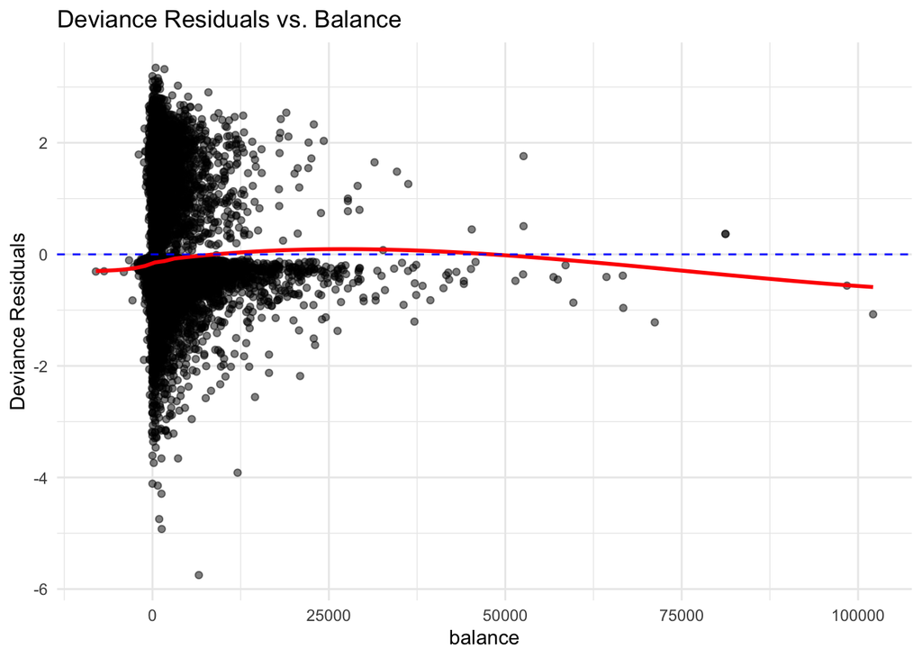

```r
# Extract deviance residuals
residuals <- residuals(glm.baseline, type = "deviance")
train_data$residuals <- residuals


p1 <- ggplot(train_data, aes(x = balance, y = residuals)) +
  geom_point(alpha = 0.5) +
  geom_smooth(method = "loess", color = "red", se = FALSE) +
  geom_hline(yintercept = 0, linetype = "dashed", color = "blue") +
  labs(title = "Deviance Residuals vs. Balance",
       y = "Deviance Residuals") +
  theme_minimal()
p1
```

### Cross-Validation

for Test Error EstimationTo obtain a reliable, low-variance estimate of the test error, we employ $K=5$ cross-validation (Chapter 5, Section 5.1.3) using the cv.glm() function. The cross-validated classification error rate is often used as a direct estimator of the true test error.

```r
cost <- function(r, pi) {
  mean(r != (pi > 0.5))
}

cv.error.baseline <- cv.glm(
  data = train_data,
  glmfit = glm.baseline,
  cost = cost,
  K = 5
)

cv_error_rate <- cv.error.baseline$delta[2]
round(cv_error_rate, 5)
```

```
## [1] 0.09841
```

# 4. Regularized Logistic Regression

To further reduce the model’s variance and potentially find a model with a lower test error—especially in the presence of many correlated predictors—we apply regularization (Chapter 6). We use the glmnet package, which requires a design matrix for predictors ($X$) and a vector for the response ($Y$).

```r
X_full <- model.matrix(y ~ . - 1, data = bank_full)
Y_full <- as.numeric(bank_full$y) - 1


X_train <- X_full[train_index, ]
Y_train <- Y_full[train_index]

X_test <- X_full[-train_index, ]
Y_test <- Y_full[-train_index]
```

### Ridge Regression ($\ell_2$ Penalty)

Ridge regression uses an $\ell_2$ penalty ($\alpha=0$) to shrink the coefficient estimates towards zero. This is a form of shrinkage that helps with multicollinearity and reduces variance, but it does not perform feature selection (no coefficients are set exactly to zero). The optimal tuning parameter $\lambda$ is selected via cross-validation.

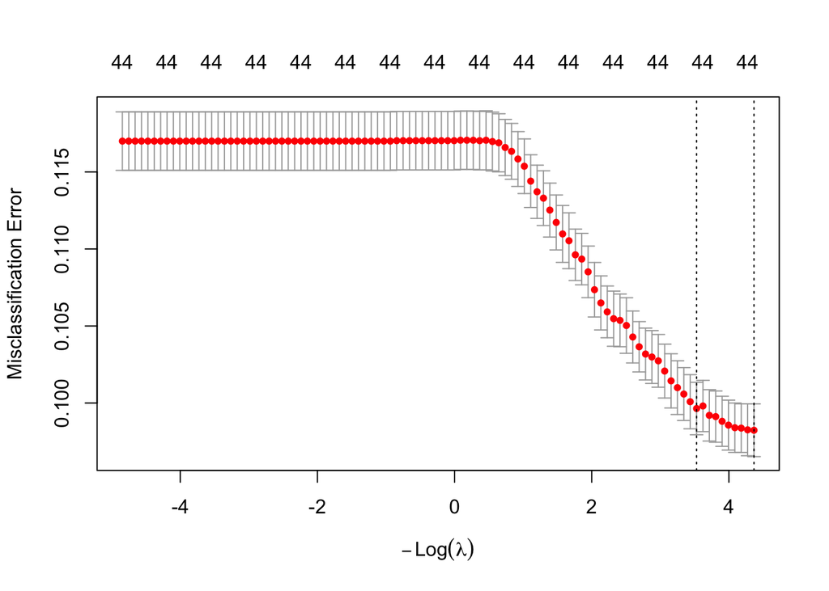

```r
cv.ridge <- cv.glmnet(X_train, Y_train,
                      alpha = 0,
                      family = "binomial",
                      type.measure = "class")
lambda.min.ridge <- cv.ridge$lambda.min

plot(cv.ridge)
```

### LASSO Regression ($\ell_1$ Penalty)

LASSO (Least Absolute Shrinkage and Selection Operator) regression uses an $\ell_1$ penalty ($\alpha=1$). A key property of the LASSO is that it forces the coefficients of some variables to be exactly zero, thereby performing automatic feature selection (Chapter 6).

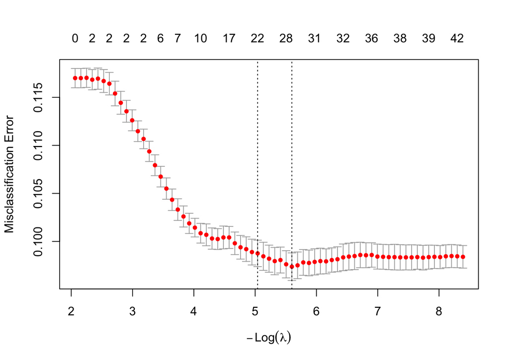

```r
cv.lasso <- cv.glmnet(X_train, Y_train,
                      alpha = 1,
                      family = "binomial",
                      type.measure = "class")
lambda.min.lasso <- cv.lasso$lambda.min

plot(cv.lasso)
```

# 5. Model Assessment and Comparison

The ultimate goal is to assess the performance of the three models (Baseline, Ridge, and LASSO) on the unseen test set. We focus on the classification error rate (or accuracy) and, crucially for this imbalanced dataset, the Sensitivity and Specificity (Chapter 4).

### Test Set Predictions

```r
baseline_prob <- predict(glm.baseline, newdata = test_data, type = "response")
baseline_pred <- factor(ifelse(baseline_prob > 0.5, "yes", "no"), levels = c("no", "yes"))

ridge_prob <- predict(cv.ridge, s = lambda.min.ridge, newx = X_test, type = "response")
ridge_pred <- factor(ifelse(ridge_prob > 0.5, "yes", "no"), levels = c("no", "yes"))

lasso_prob <- predict(cv.lasso, s = lambda.min.lasso, newx = X_test, type = "response")
lasso_pred <- factor(ifelse(lasso_prob > 0.5, "yes", "no"), levels = c("no", "yes"))
```

### Confusion Matrices and Metrics

The confusion matrix (Chapter 4) provides a detailed breakdown of the model’s performance by counting True Positives (TP), True Negatives (TN), False Positives (FP), and False Negatives (FN).

```r
cm_baseline <- confusionMatrix(baseline_pred, test_data$y, positive = "yes")
cm_ridge <- confusionMatrix(ridge_pred, test_data$y, positive = "yes")
cm_lasso <- confusionMatrix(lasso_pred, test_data$y, positive = "yes")

metrics <- data.frame(
  Model = c("Baseline Logit", "Ridge Logit", "LASSO Logit"),
  Accuracy = c(cm_baseline$overall['Accuracy'], cm_ridge$overall['Accuracy'], cm_lasso$overall['Accuracy']),
  Sensitivity = c(cm_baseline$byClass['Sensitivity'], cm_ridge$byClass['Sensitivity'], cm_lasso$byClass['Sensitivity']),
  Specificity = c(cm_baseline$byClass['Specificity'], cm_ridge$byClass['Specificity'], cm_lasso$byClass['Specificity'])
)
metrics
```

```
##            Model  Accuracy Sensitivity Specificity
## 1 Baseline Logit 0.8995686   0.3282876   0.9752004
## 2    Ridge Logit 0.8982413   0.2800378   0.9800852
## 3    LASSO Logit 0.8981307   0.3008515   0.9772044
```

### ROC Curve and AUC Comparison

The Receiver Operating Characteristic (ROC) curve and the Area Under the Curve (AUC) (Chapter 4, Section 4.4) are threshold-independent measures of model discrimination. The AUC represents the probability that the model will rank a randomly chosen positive observation higher than a randomly chosen negative observation.

```r
roc_baseline <- roc(test_data$y, baseline_prob)
roc_ridge <- roc(test_data$y, as.numeric(ridge_prob))
roc_lasso <- roc(test_data$y, as.numeric(lasso_prob))
```

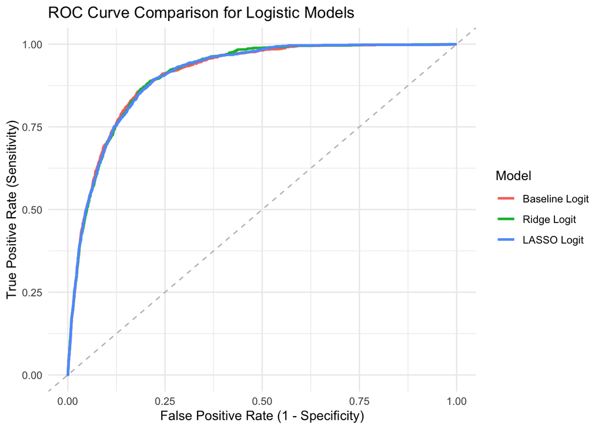

```r
roc_data <- data.frame(
  fpr = c(1 - roc_baseline$specificities, 1 - roc_ridge$specificities, 1 - roc_lasso$specificities),
  tpr = c(roc_baseline$sensitivities, roc_ridge$sensitivities, roc_lasso$sensitivities),
  Model = factor(c(rep("Baseline Logit", length(roc_baseline$specificities)),
                   rep("Ridge Logit", length(roc_ridge$specificities)),
                   rep("LASSO Logit", length(roc_lasso$specificities))),
                 levels = c("Baseline Logit", "Ridge Logit", "LASSO Logit"))
)

ggplot(roc_data, aes(x = fpr, y = tpr, color = Model)) +
  geom_line(linewidth = 1) +
  geom_abline(linetype = "dashed", color = "grey") +
  labs(
    title = "ROC Curve Comparison for Logistic Models",
    x = "False Positive Rate (1 - Specificity)",
    y = "True Positive Rate (Sensitivity)"
  ) +
  theme_minimal()
```

```r
auc_values <- data.frame(
  Model = c("Baseline Logit", "Ridge Logit", "LASSO Logit"),
  AUC = c(auc(roc_baseline), auc(roc_ridge), auc(roc_lasso))
)
auc_values
```

```
##            Model       AUC
## 1 Baseline Logit 0.9074607
## 2    Ridge Logit 0.9080043
## 3    LASSO Logit 0.9072429
```

All three models yield a very similar AUC of approximately $0.90$. The ROC curves are virtually identical, demonstrating that both the Ridge and LASSO regularization penalties provided negligible improvement in the overall power of the model to distinguish between the two classes when compared to the simpler Baseline logistic regression. This consistent performance confirms the observation from the confusion matrices: while the logistic models are good at discrimination (AUC $> 0.5$), they lack the flexibility needed to substantially reduce the bias and improve the classification of the highly valuable minority class.

## 3.4 K-Nearest Neighbors (KNN)

- Standardize numeric predictors.
- Perform CV to tune **k** .
- Report best k and corresponding CV error.
- Discuss bias-variance behavior.

## 3.5 Generalized Additive Models (GAM)

- Fit GAM with smoothing splines for continuous variables.
- Use CV to choose smoothing parameters.
- Examine partial effect plots for interpretability.

## 3.6 Boosting (Most Flexible Model)

- Fit gradient boosting classifier (e.g., `gbm` or `xgboost`).
- Use cross-validation for:
  - number of trees,
  - interaction depth,
  - learning rate.
- Discuss complexity vs interpretability tradeoff. This model will be our benchmark non-interpretable model to compare interpretable models fitted above.

# 4. Results — Model Assessment & Comparison

## 4.1 Test Set Performance

For each model: - Confusion matrix  
- Accuracy and misclassification rate  
- Sensitivity / specificity (important for minority class)  
- ROC curves and AUC

## 4.2 Comparative Evaluation

- Table summarizing all test-set performance metrics.
- Visual comparison of ROC curves.
- Discuss interpretability vs predictive quality.